# Climate Trends in Barrow, Alaska

Katie Graham

2/13/2017

```r
import$TMAX[import$TMAX==-9999] = NA
import$TMIN[import$TMIN==-9999] = NA

import$SNOW[import$SNOW==-9999] = NA
import$SNWD[import$SNWD==-9999] = NA
```

### Selecting for 3 Months – December, January, February

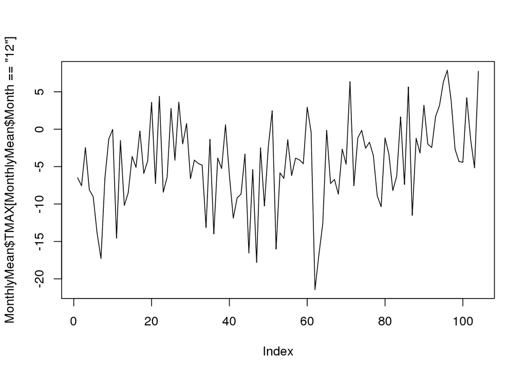

```r
plot(MonthlyMean$TMAX[MonthlyMean$Month=="12"], ty='l')
```

```r
plot(TMAX~YEAR, data=MonthlyMean[MonthlyMean$Month=="12",], ty='l')
December.lm <- lm(TMAX~YEAR, data=MonthlyMean[MonthlyMean$Month=="12",])
summary(December.lm)
```

```
##
## Call:
## lm(formula = TMAX ~ YEAR, data = MonthlyMean[MonthlyMean$Month ==
##     "12", ])
##
## Residuals:
##      Min       1Q   Median       3Q      Max
## -17.5445  -3.1977   0.3146   3.6441  10.5335
##
## Coefficients:
##               Estimate Std. Error t value Pr(>|t|)
## (Intercept) -114.41336   35.04872  -3.264  0.00149 **
## YEAR           0.05598    0.01784   3.137  0.00223 **
## ---
## Signif. codes:  0 '***' 0.001 '**' 0.01 '*' 0.05 '.' 0.1 ' ' 1
##
## Residual standard error: 5.63 on 102 degrees of freedom
## Multiple R-squared:  0.08801,    Adjusted R-squared:  0.07906
## F-statistic: 9.843 on 1 and 102 DF,  p-value: 0.002229
```

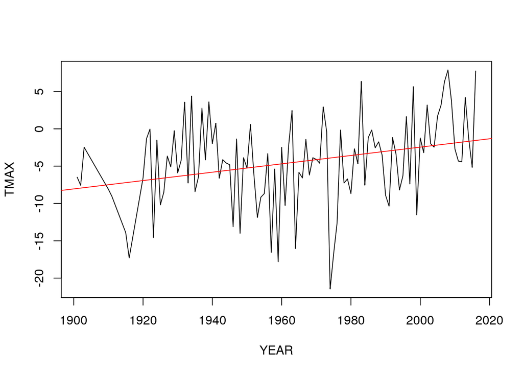

```r
abline(coef(December.lm), col="red")
```

Now, the change is 0.0559809 degrees/year or 5.598 degrees/100 years with a probability of 0.0022. We can reject the null hypothesis that there is no relationship, since the p value is less than 0.05.

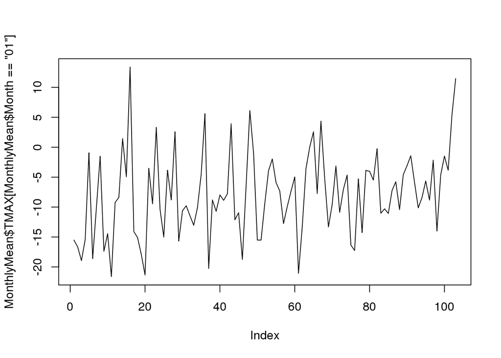

```r
plot(MonthlyMean$TMAX[MonthlyMean$Month=="01"], ty='l')
```

```r
plot(TMAX~YEAR, data=MonthlyMean[MonthlyMean$Month=="01",], ty='l')
January.lm <- lm(TMAX~YEAR, data=MonthlyMean[MonthlyMean$Month=="01",])

summary(January.lm)
```

```
##
## Call:
## lm(formula = TMAX ~ YEAR, data = MonthlyMean[MonthlyMean$Month ==
##     "01", ])
##
## Residuals:
##      Min       1Q   Median       3Q      Max
## -13.7964  -4.6133  -0.2991   3.0009  23.5887
##
## Coefficients:
##               Estimate Std. Error t value Pr(>|t|)
## (Intercept) -136.01676   42.85871  -3.174  0.00200 **
## YEAR           0.06519    0.02180   2.990  0.00351 **
## ---
## Signif. codes:  0 '***' 0.001 '**' 0.01 '*' 0.05 '.' 0.1 ' ' 1
##
## Residual standard error: 6.781 on 101 degrees of freedom
## Multiple R-squared:  0.08131,    Adjusted R-squared:  0.07222
## F-statistic:  8.94 on 1 and 101 DF,  p-value: 0.003505
```

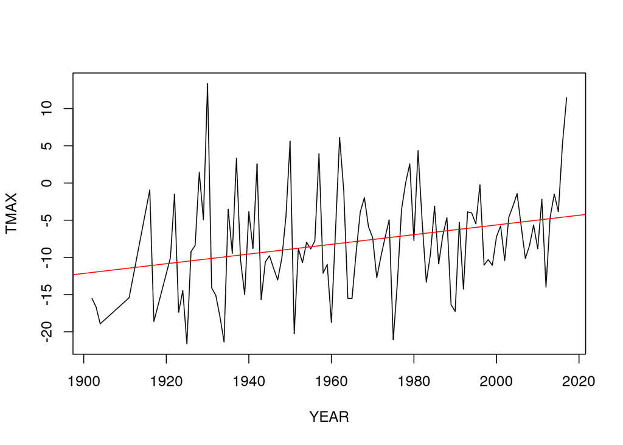

```r
abline(coef(January.lm), col="red")
```

Now, the change is 0.0651892 degrees/year or 6.519 degrees/100 years with a probability of 0.0035. We can reject the null hypothesis that there is no relationship, since the p value is less than 0.05.

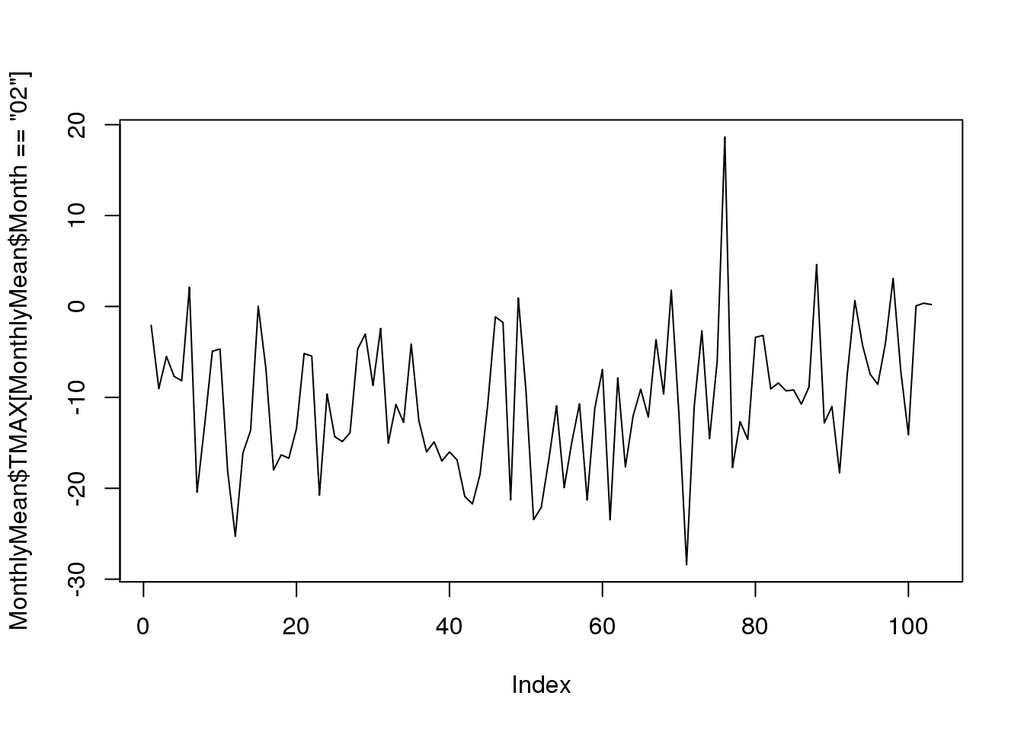

```r
plot(MonthlyMean$TMAX[MonthlyMean$Month=="02"], ty='l')
```

```r
plot(TMAX~YEAR, data=MonthlyMean[MonthlyMean$Month=="02",], ty='l')
February.lm <- lm(TMAX~YEAR, data=MonthlyMean[MonthlyMean$Month=="02",])
summary(February.lm)
```

```
##
## Call:
## lm(formula = TMAX ~ YEAR, data = MonthlyMean[MonthlyMean$Month ==
##     "02", ])
##
## Residuals:
##      Min       1Q   Median       3Q      Max
## -19.0439  -4.8877  -0.5469   5.6230  27.7700
##
## Coefficients:
##               Estimate Std. Error t value Pr(>|t|)
## (Intercept) -105.67630   47.36487  -2.231   0.0279 *
## YEAR           0.04854    0.02411   2.014   0.0467 *
## ---
## Signif. codes:  0 '***' 0.001 '**' 0.01 '*' 0.05 '.' 0.1 ' ' 1
##
## Residual standard error: 7.475 on 101 degrees of freedom
## Multiple R-squared:  0.03859,    Adjusted R-squared:  0.02908
## F-statistic: 4.055 on 1 and 101 DF,  p-value: 0.04671
```

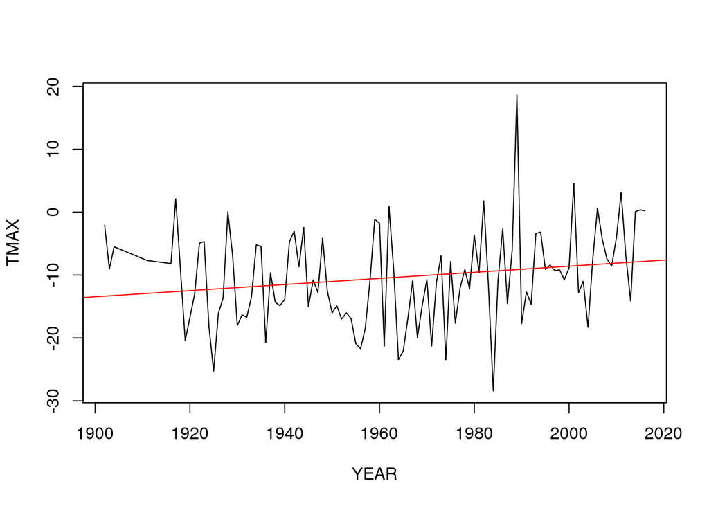

```r
abline(coef(February.lm), col="red")
```

Now, the change is 0.0485416 degrees/year or 4.854 degrees/100 years with a probability of 0.0467. We can reject the null hypothesis that there is no relationship, since the p value is less than 0.05.

## TMIN

1. We create a monthly mean for each month.

```r
MonthlyMeanTMIN = aggregate(TMIN ~ Month + Year, BarrowAlaska, mean)

MonthlyMeanTMIN$YEAR = as.numeric(MonthlyMeanTMIN$Year)
head(MonthlyMeanTMIN)
```

```
##   Month Year       TMIN YEAR
## 1    09 1901  27.533333 1901
## 2    10 1901   8.548387 1901
## 3    11 1901 -11.700000 1901
## 4    12 1901 -17.193548 1901
## 5    01 1902 -27.483871 1902
## 6    02 1902 -10.928571 1902
```

2. Now we plot the mins, and again, find tons of scatter.

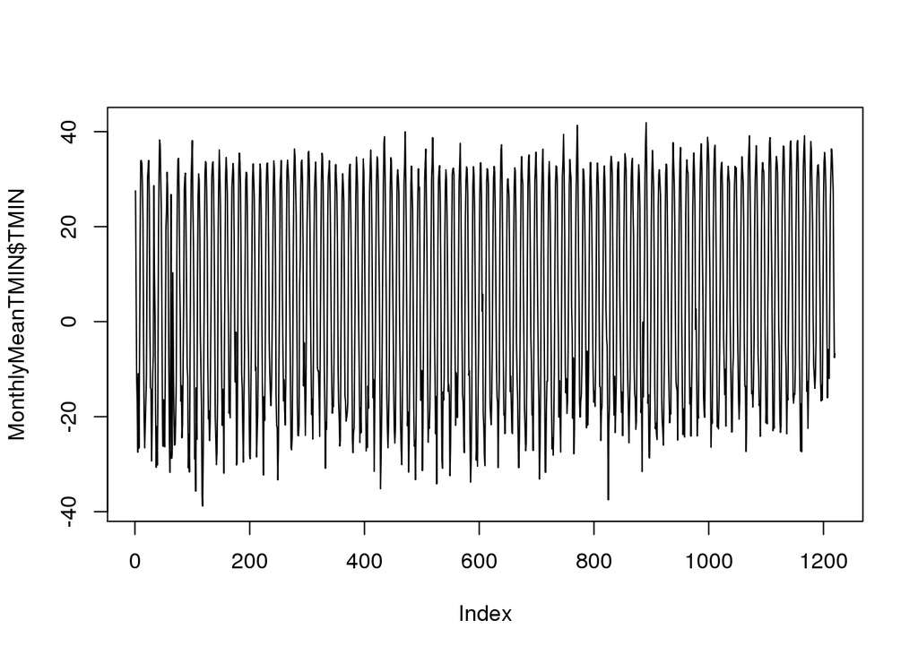

```r
plot(MonthlyMeanTMIN$TMIN, ty='l')
```

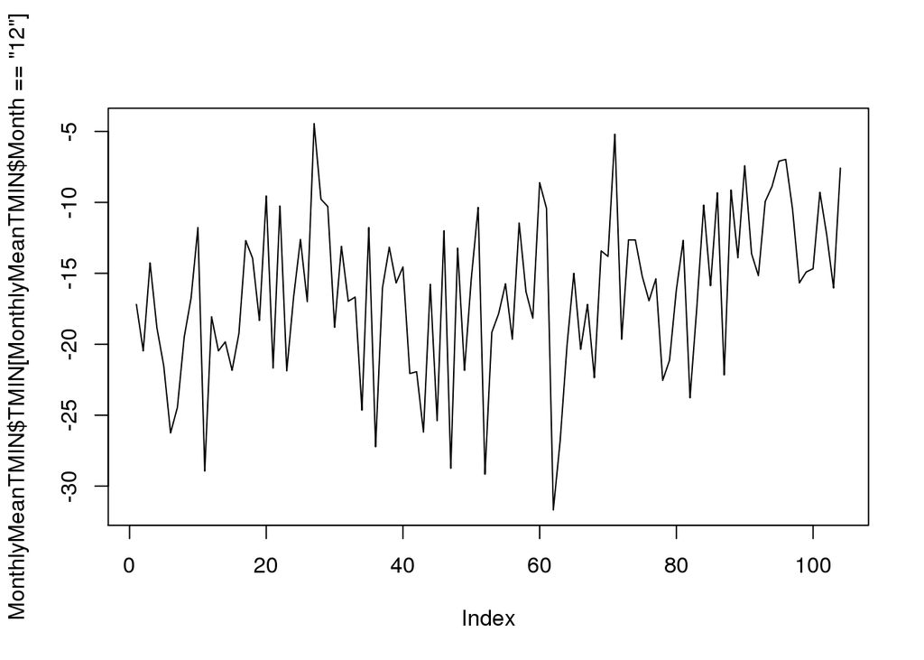

```r
plot(MonthlyMeanTMIN$TMIN[MonthlyMeanTMIN$Month=="12"], ty='l')
```

```r
plot(TMIN~YEAR, data=MonthlyMeanTMIN[MonthlyMeanTMIN$Month=="12",], ty='l')
Dec.lm <- lm(TMIN~YEAR, data=MonthlyMeanTMIN[MonthlyMeanTMIN$Month=="12",])
summary(Dec.lm)
```

```
##
## Call:
## lm(formula = TMIN ~ YEAR, data = MonthlyMeanTMIN[MonthlyMeanTMIN$Month ==
##     "12", ])
##
## Residuals:
##      Min       1Q   Median       3Q      Max
## -15.8270  -2.9033   0.5335   4.3140  13.4337
##
## Coefficients:
##               Estimate Std. Error t value Pr(>|t|)
## (Intercept) -130.61672   33.91430  -3.851 0.000205 ***
## YEAR           0.05814    0.01727   3.367 0.001072 **
## ---
## Signif. codes:  0 '***' 0.001 '**' 0.01 '*' 0.05 '.' 0.1 ' ' 1
##
## Residual standard error: 5.448 on 102 degrees of freedom
## Multiple R-squared:    0.1,  Adjusted R-squared:  0.09122
## F-statistic: 11.34 on 1 and 102 DF,  p-value: 0.001072
```

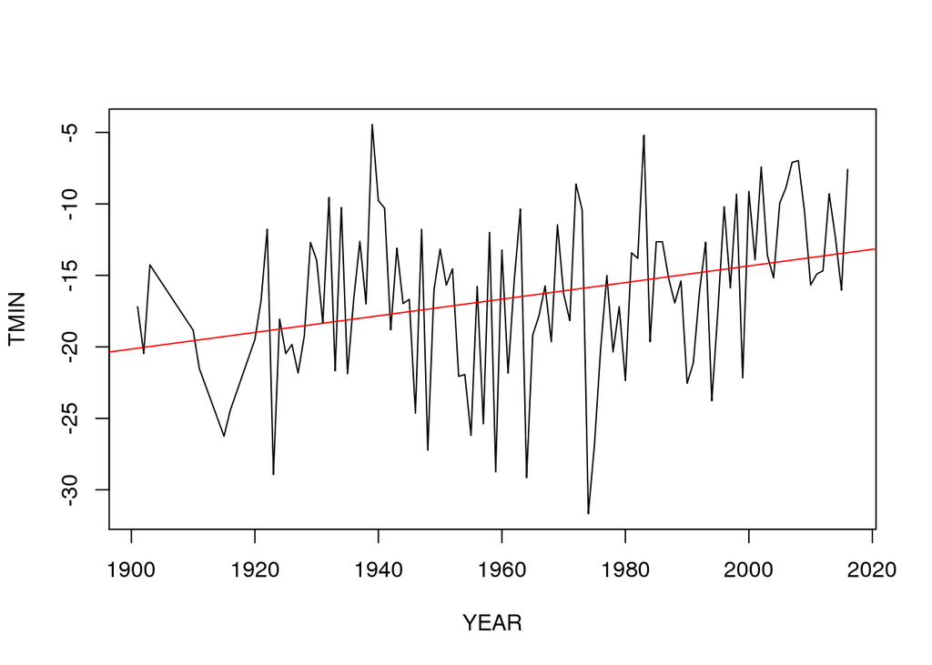

```r
abline(coef(Dec.lm), col="red")
```

3. In this case, we get a slope, 0.058139 degrees/year and a probability of 0.0010718 and an r-squared of 0.1. Cool! As we might expect, the a small amount of the variance is explained by the “Month”. Many things predict temperature, that year is one, is quite problematic.
4. What we have not determined is the cause. So, be careful when you describe the results, cause and effect cannot be analyzed using this method.

## TMAX

1. We create a monthly mean for each month.

```r
MonthlyMeanTMAX = aggregate(TMAX ~ Month + Year, BarrowAlaska, mean)

MonthlyMeanTMAX$YEAR = as.numeric(MonthlyMeanTMAX$Year)
head(MonthlyMeanTMAX)
```

```
##   Month Year        TMAX YEAR
## 1    09 1901  37.8000000 1901
## 2    10 1901  23.3000000 1901
## 3    11 1901  -0.7333333 1901
## 4    12 1901  -6.4838710 1901
## 5    01 1902 -15.5161290 1902
## 6    02 1902  -2.0714286 1902
```

2. Now we plot the maximums, and again, find tons of scatter.

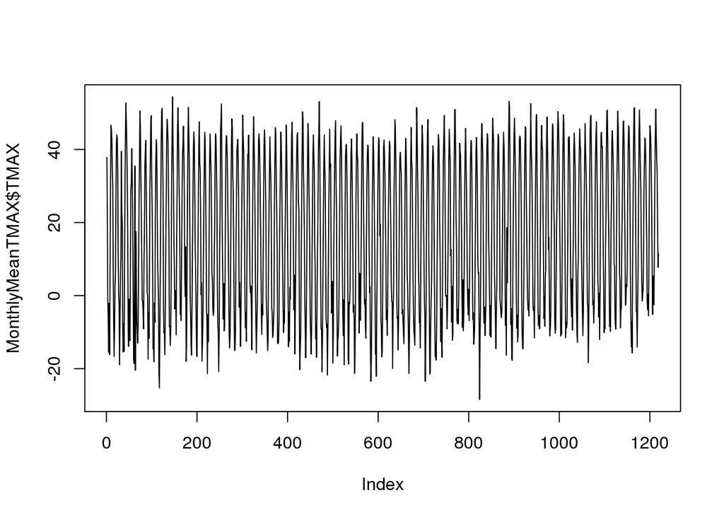

```r
plot(MonthlyMeanTMAX$TMAX, ty='l')
```

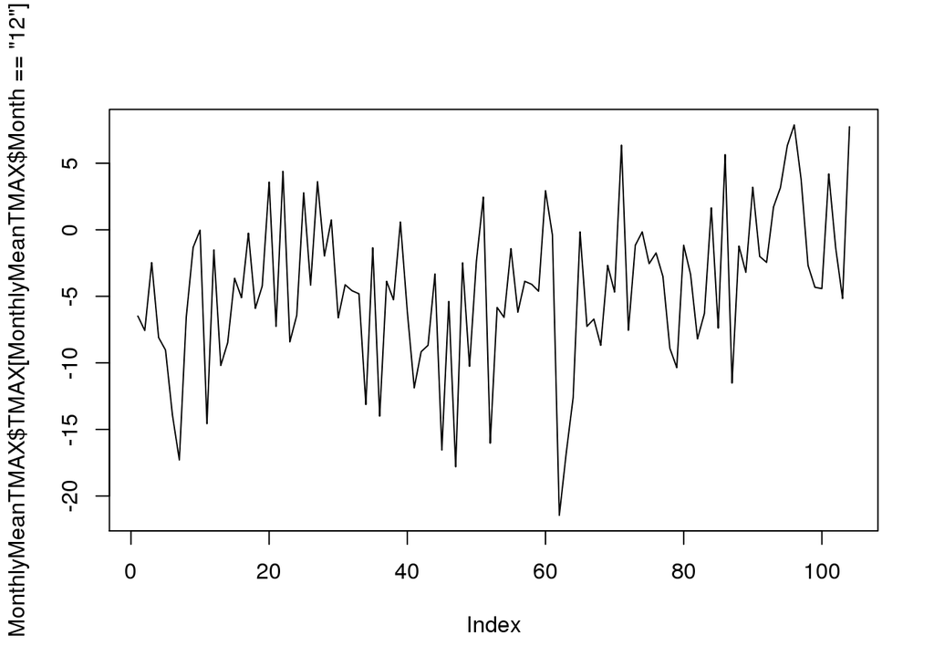

```r
plot(MonthlyMeanTMAX$TMAX[MonthlyMeanTMAX$Month=="12"], ty='l')
```

```r
plot(TMAX~YEAR, data=MonthlyMeanTMAX[MonthlyMeanTMAX$Month=="12",], ty='l')
Dec.lm <- lm(TMAX~YEAR, data=MonthlyMeanTMAX[MonthlyMeanTMAX$Month=="12",])
summary(Dec.lm)
```

```
##
## Call:
## lm(formula = TMAX ~ YEAR, data = MonthlyMeanTMAX[MonthlyMeanTMAX$Month ==
##     "12", ])
##
## Residuals:
##      Min       1Q   Median       3Q      Max
## -17.5445  -3.1977   0.3146   3.6441  10.5335
##
## Coefficients:
##               Estimate Std. Error t value Pr(>|t|)
## (Intercept) -114.41336   35.04872  -3.264  0.00149 **
## YEAR           0.05598    0.01784   3.137  0.00223 **
## ---
## Signif. codes:  0 '***' 0.001 '**' 0.01 '*' 0.05 '.' 0.1 ' ' 1
##
## Residual standard error: 5.63 on 102 degrees of freedom
## Multiple R-squared:  0.08801,    Adjusted R-squared:  0.07906
## F-statistic: 9.843 on 1 and 102 DF,  p-value: 0.002229
```

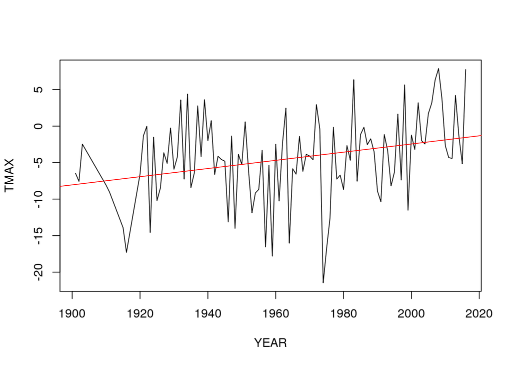

```r
abline(coef(Dec.lm), col="red")
```

3. In this case, we get a slope, 0.0559809 degrees/year and a probability of 0.0022289 and an r-squared of 0.088. Cool! As we might expect, the a small amount of the variance is explained by the “Month”. Many things predict temperature, that year is one, is quite problematic.
4. What we have not determined is the cause. So, be careful when you describe the results, cause and effect cannot be analyzed using this method.

# Departure from Mean

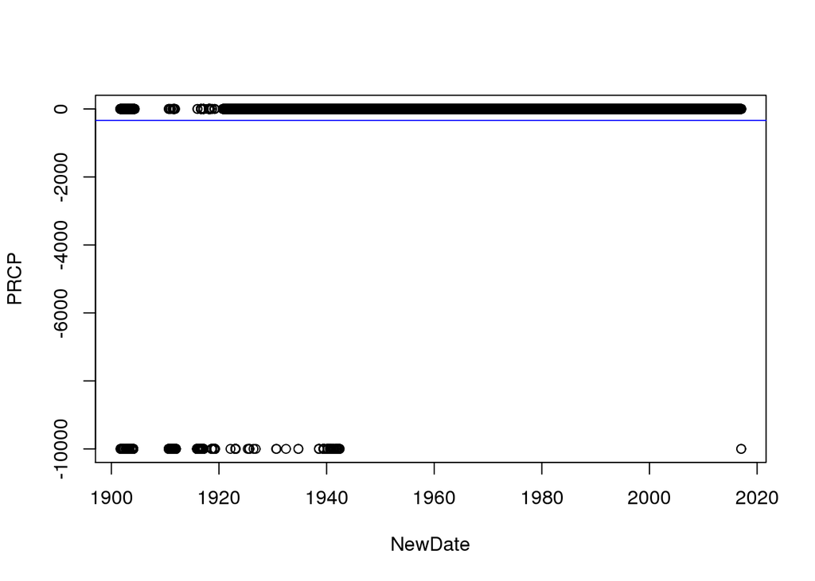

```r
PRCP_mean = mean(BarrowAlaska$PRCP, na.rm=T)

plot(PRCP~NewDate, data=BarrowAlaska)
abline(h=PRCP_mean, col="blue")
```

## Experimental Portion — Precipitation

Precipiation might depend more on the departure from the mean (often referred as as normal, whatever that means!). I think it’s worth pursuing, but haven’t finished the analysis yet.

First, we need a “mean” – The IPCC uses 1961-1990 as a norm, I don’t know what is the standard for California, so we should look that up.

Second, we need to remove the missing values and evalaute which years have complete years. If you are missing rainy months, then the whole year should be thrown out – but what about partial years in the drought season?

Third, we will need to decide what level of aggredation – monthly, yearly, etc.

Fourth, in CA the water year starts in Oct 1. Should we follow the same convention?

```r
BarrowAlaska$PRCP[BarrowAlaska$PRCP==-9999] <- NA
YearlySum = aggregate(PRCP ~ Year, BarrowAlaska, sum)
YearlySum$YEAR = as.numeric(YearlySum$Year)
YearlyMean = mean(YearlySum$PRCP)
```

A yearly mean, based on the annual sum for the entire records. Not sure this is appropriate.

Figure has points of the yearly sum of rainfall and the blue line mean. The greenline is the trend and red line is a five year running average, I think! I am still trying to understand what the code is doing.

```r
plot(PRCP~YEAR, data=YearlySum, las=1, ty="p")
abline(h=YearlyMean, col="blue")
YearlySum.lm = lm(PRCP~YEAR, data=YearlySum)
abline(coef(YearlySum.lm), col="green")

n <- 5
k <- rep(1/n, n)
k
```

```
## [1] 0.2 0.2 0.2 0.2 0.2
```

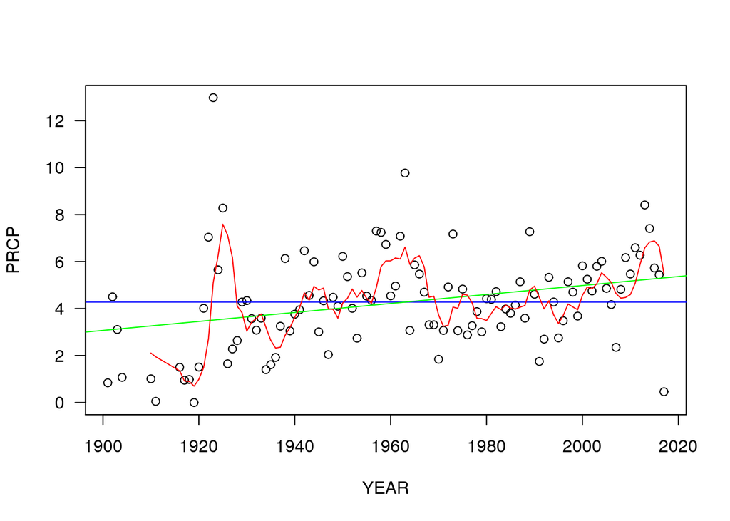

```r
y_lag <- stats::filter(YearlySum$PRCP, k, sides=1)
lines(YearlySum$YEAR, y_lag, col="red")
```

```r
summary(YearlySum.lm)
```

```
##
## Call:
## lm(formula = PRCP ~ YEAR, data = YearlySum)
##
## Residuals:
##     Min      1Q  Median      3Q     Max
## -4.8468 -1.3155 -0.0837  0.7802  9.4703
##
## Coefficients:
##               Estimate Std. Error t value Pr(>|t|)
## (Intercept) -33.252757  11.889190  -2.797  0.00613 **
## YEAR          0.019117   0.006056   3.157  0.00208 **
## ---
## Signif. codes:  0 '***' 0.001 '**' 0.01 '*' 0.05 '.' 0.1 ' ' 1
##
## Residual standard error: 2.007 on 106 degrees of freedom
## Multiple R-squared:  0.08594,    Adjusted R-squared:  0.07732
## F-statistic: 9.967 on 1 and 106 DF,  p-value: 0.002076
```

Other attempts that didn’t work!

```r
YearlySum2 = subset(YearlySum, select=c(PRCP))
YearlyMean = mean(YearlySum2$PRCP)

#filter(YearlySum2)



#Doesn't work...
# ma <- function(x,n=5){filter(x,rep(1/n,n), sides=2)}
# ma(YearlySum$PRCP)


yearlyts =ts(YearlySum2)
str(yearlyts)
```

```
##  Time-Series [1:108, 1] from 1 to 108: 0.84 4.5 3.11 1.07 1.01 0.05 1.5 0.95 0.98 0 ...
##  - attr(*, "dimnames")=List of 2
##   ..$ : NULL
##   ..$ : chr "PRCP"
```

yearlyts.lag = lag(yearlyts, 5)[6:112,]; head(yearlyts.lag)

plot(yearlyts, lty = 1, col = 3)

lines(yearlyts.lag)

YearlySum$Departure = YearlyMean - YearlySum$PRCP YearlySum$YEAR = as.numeric(YearlySum$Year)

plot(PRCP~YEAR, data=YearlySum, las=1, ty=“l”) abline(h=YearlyMean, col=“blue”)

lines(Departure ~ YEAR, data=YearlySum, col=“red”)

## SNWD - Snow Depth (mm)

1. We create a monthly mean for each month.

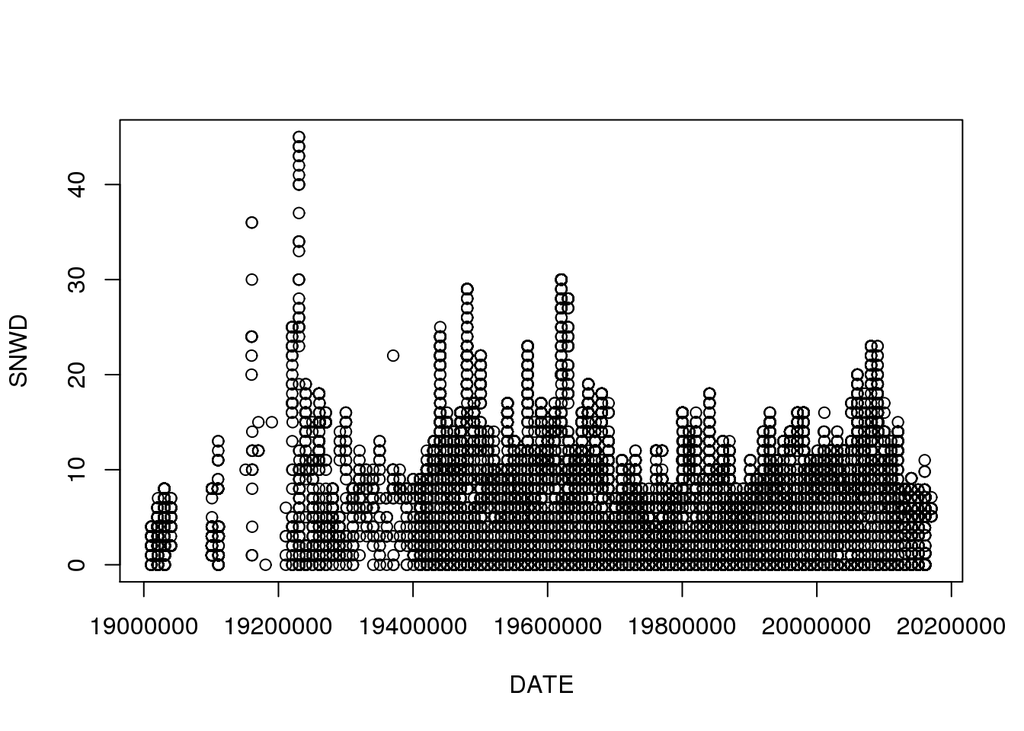

```r
plot(SNWD~DATE, import)
```

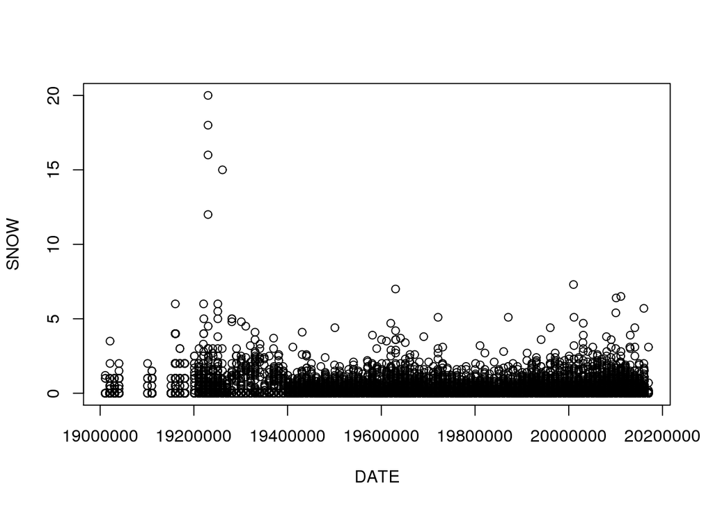

```r
plot(SNOW~DATE, import)
```

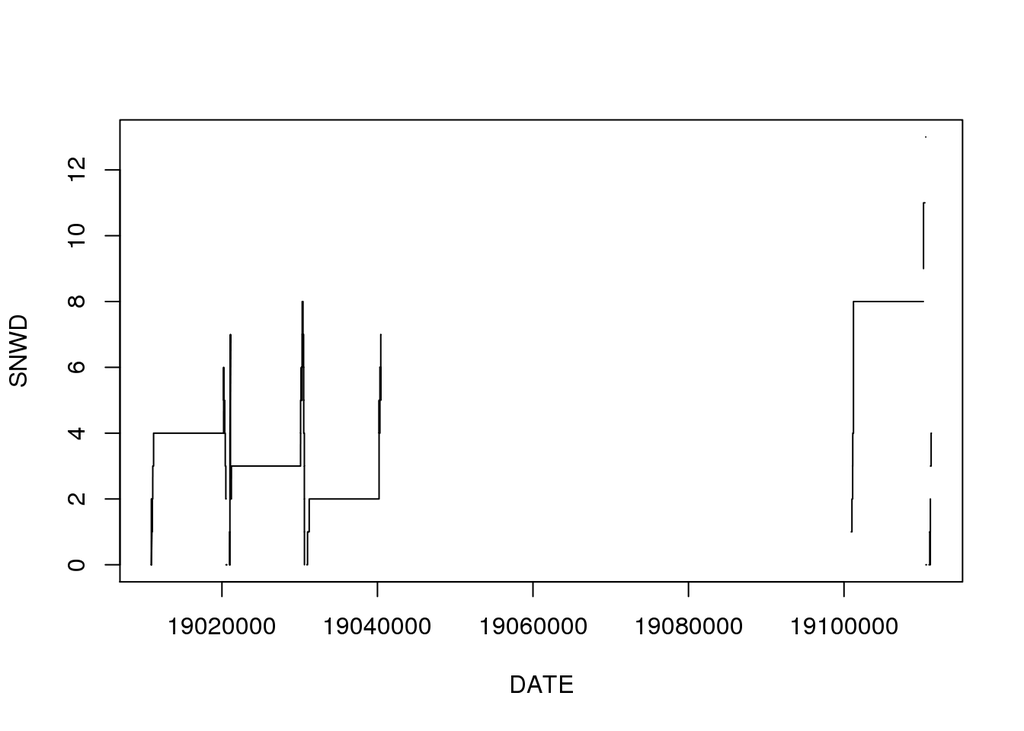

```r
plot(SNWD~DATE, import[import$DATE<19131231,], ty='l')
```

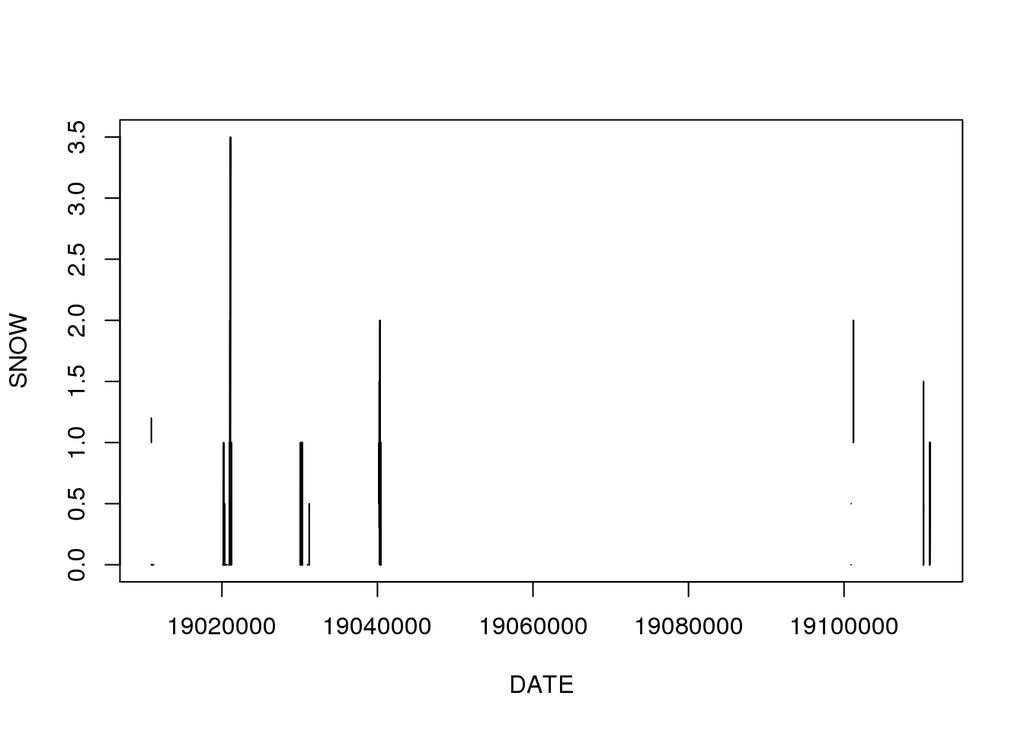

```r
plot(SNOW~DATE, import[import$DATE<19130102,], ty='l')
```

```r
strDates <- as.character(import$DATE)
head(strDates)
```

```
## [1] "19010901" "19010902" "19010903" "19010904" "19010905" "19010906"
```

```r
import$NewDate <- as.Date(strDates, "%Y%m%d")
```

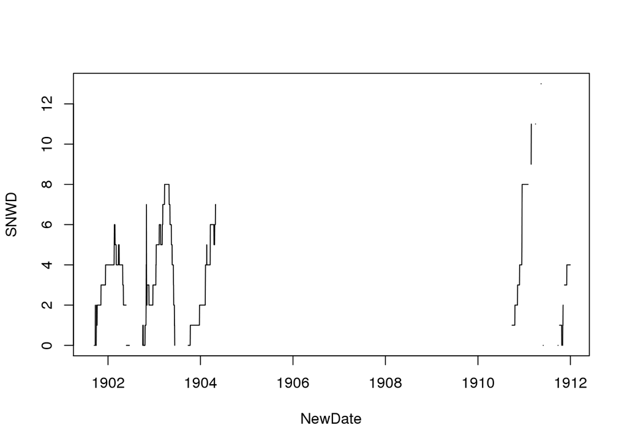

```r
plot(SNWD~NewDate, import[import$DATE<19130102,], ty='l')
```

```r
# Linear Model
BarrowAlaska.lm <- lm(SNOW~NewDate, data=BarrowAlaska)
summary(BarrowAlaska.lm)
```

```
##
## Call:
## lm(formula = SNOW ~ NewDate, data = BarrowAlaska)
##
## Residuals:
##     Min      1Q  Median      3Q     Max
## -0.1075 -0.1008 -0.0946 -0.0886 19.9121
##
## Coefficients:
##              Estimate Std. Error t value Pr(>|t|)
## (Intercept) 9.768e-02  2.093e-03   46.67  < 2e-16 ***
## NewDate     5.711e-07  1.976e-07    2.89  0.00385 **
## ---
## Signif. codes:  0 '***' 0.001 '**' 0.01 '*' 0.05 '.' 0.1 ' ' 1
##
## Residual standard error: 0.3921 on 35254 degrees of freedom
##   (1900 observations deleted due to missingness)
## Multiple R-squared:  0.0002369,  Adjusted R-squared:  0.0002085
## F-statistic: 8.352 on 1 and 35254 DF,  p-value: 0.003854
```

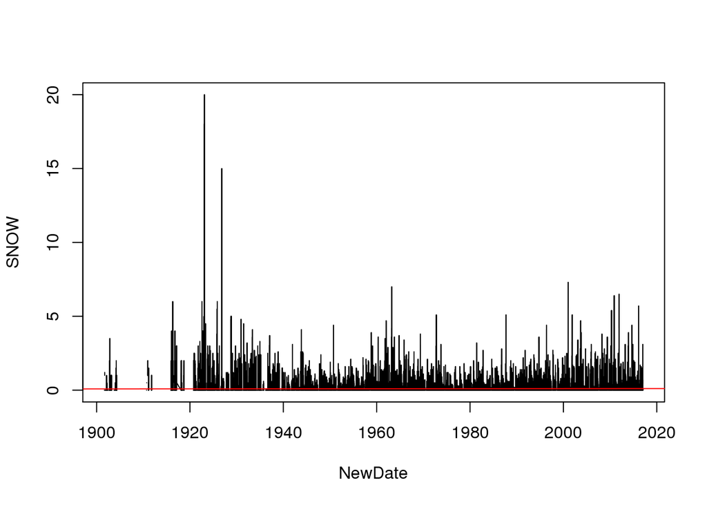

```r
plot(SNOW~NewDate, BarrowAlaska, ty='l')
abline(coef(BarrowAlaska.lm), col='red')
```

```r
MonthlyMeanSNWD = aggregate(SNWD ~ Month + Year, BarrowAlaska, mean)

MonthlyMeanSNWD$YEAR = as.numeric(MonthlyMeanSNWD$Year)
head(MonthlyMeanSNWD)
```

```
##   Month Year     SNWD YEAR
## 1    09 1901 0.200000 1901
## 2    10 1901 1.806452 1901
## 3    11 1901 2.800000 1901
## 4    12 1901 3.612903 1901
## 5    01 1902 4.000000 1902
## 6    02 1902 4.571429 1902
```

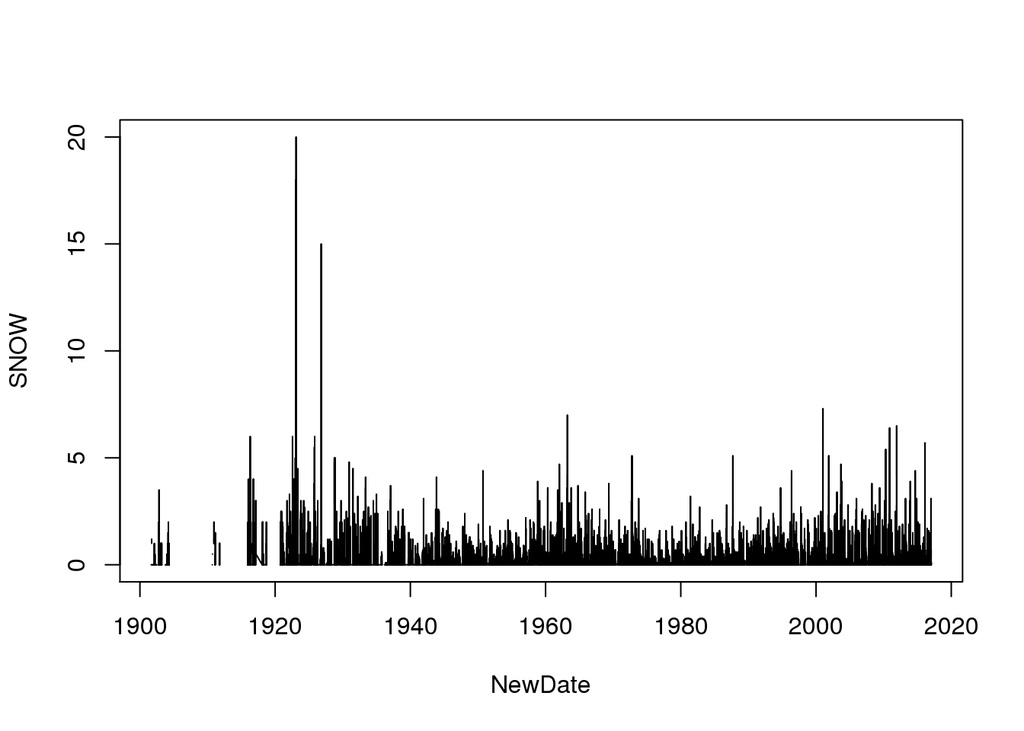

```r
plot(SNOW~NewDate, BarrowAlaska, ty='l')
```

```r
# Linear Model
BarrowAlaska.lm <- lm(SNOW~NewDate, data=BarrowAlaska)
summary(BarrowAlaska.lm)
```

```
##
## Call:
## lm(formula = SNOW ~ NewDate, data = BarrowAlaska)
##
## Residuals:
##     Min      1Q  Median      3Q     Max
## -0.1075 -0.1008 -0.0946 -0.0886 19.9121
##
## Coefficients:
##              Estimate Std. Error t value Pr(>|t|)
## (Intercept) 9.768e-02  2.093e-03   46.67  < 2e-16 ***
## NewDate     5.711e-07  1.976e-07    2.89  0.00385 **
## ---
## Signif. codes:  0 '***' 0.001 '**' 0.01 '*' 0.05 '.' 0.1 ' ' 1
##
## Residual standard error: 0.3921 on 35254 degrees of freedom
##   (1900 observations deleted due to missingness)
## Multiple R-squared:  0.0002369,  Adjusted R-squared:  0.0002085
## F-statistic: 8.352 on 1 and 35254 DF,  p-value: 0.003854
```

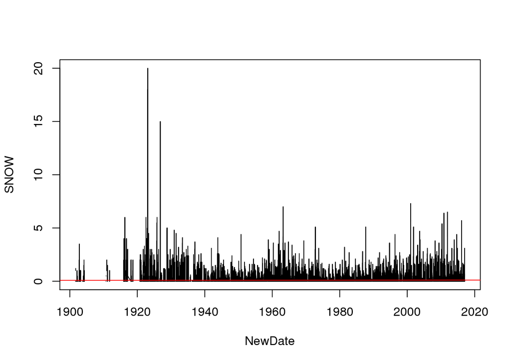

```r
plot(SNOW~NewDate, BarrowAlaska, ty='l')
abline(coef(BarrowAlaska.lm), col='red')
```

```r
# Get months
BarrowAlaska$Month = months(BarrowAlaska$NewDate) # Creates problems.
BarrowAlaska$Month = format(as.Date(BarrowAlaska$NewDate), format = "%m")
BarrowAlaska$Year = format(BarrowAlaska$NewDate, format="%Y")
```

```r
MonthlyMean = aggregate(SNOW ~ Month + Year, BarrowAlaska, mean)

MonthlyMean$YEAR = as.numeric(MonthlyMean$Year)
MonthlyMean$MONTH = as.numeric(MonthlyMean$Month)


# Frank -- change mean to sd and you'll get standard deviation for each month/year.

MonthlySD = aggregate(SNOW ~ Month + Year, BarrowAlaska, sd)

MonthlySD$YEAR = as.numeric(MonthlySD$Year)
MonthlySD$MONTH = as.numeric(MonthlySD$Month)
MonthlySD$NewDate = MonthlySD$YEAR + (MonthlySD$MONTH - 1)/12

head(MonthlySD)
```

```
##   Month Year      SNOW YEAR MONTH  NewDate
## 1    09 1901 0.5715476 1901     9 1901.667
## 2    10 1901 0.0000000 1901    10 1901.750
## 3    11 1901 0.0000000 1901    11 1901.833
## 4    12 1901 0.4472136 1901    12 1901.917
## 5    01 1902 0.0000000 1902     1 1902.000
## 6    02 1902 0.2622653 1902     2 1902.083
```

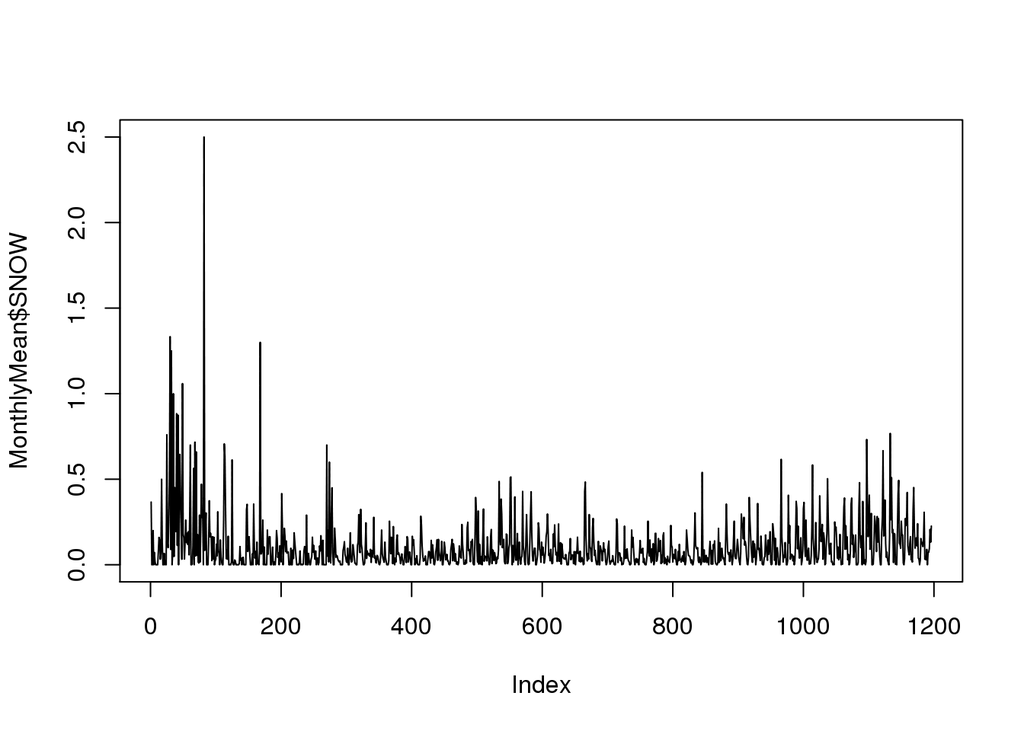

```r
plot(MonthlyMean$SNOW, ty='l')
```

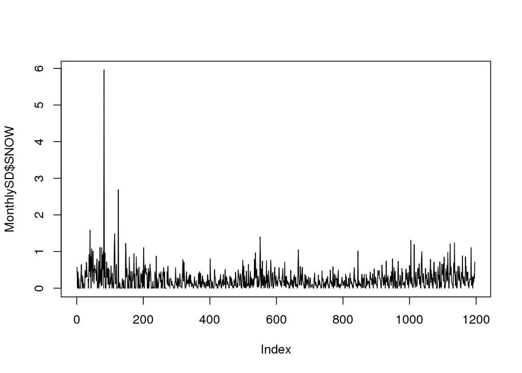

```r
plot(MonthlySD$SNOW, ty='l')
```

```r
plot(SNOW~ NewDate, data=MonthlySD, ty='l')
SD.lm <- lm(SNOW~NewDate, data=MonthlySD)
summary(SD.lm)
```

```
##
## Call:
## lm(formula = SNOW ~ NewDate, data = MonthlySD)
##
## Residuals:
##     Min      1Q  Median      3Q     Max
## -0.2681 -0.1782 -0.0634  0.1001  5.7008
##
## Coefficients:
##               Estimate Std. Error t value Pr(>|t|)
## (Intercept)  1.2205225  0.5687618   2.146   0.0321 *
## NewDate     -0.0005008  0.0002892  -1.732   0.0835 .
## ---
## Signif. codes:  0 '***' 0.001 '**' 0.01 '*' 0.05 '.' 0.1 ' ' 1
##
## Residual standard error: 0.2968 on 1187 degrees of freedom
##   (7 observations deleted due to missingness)
## Multiple R-squared:  0.002521,   Adjusted R-squared:  0.001681
## F-statistic:     3 on 1 and 1187 DF,  p-value: 0.08352
```

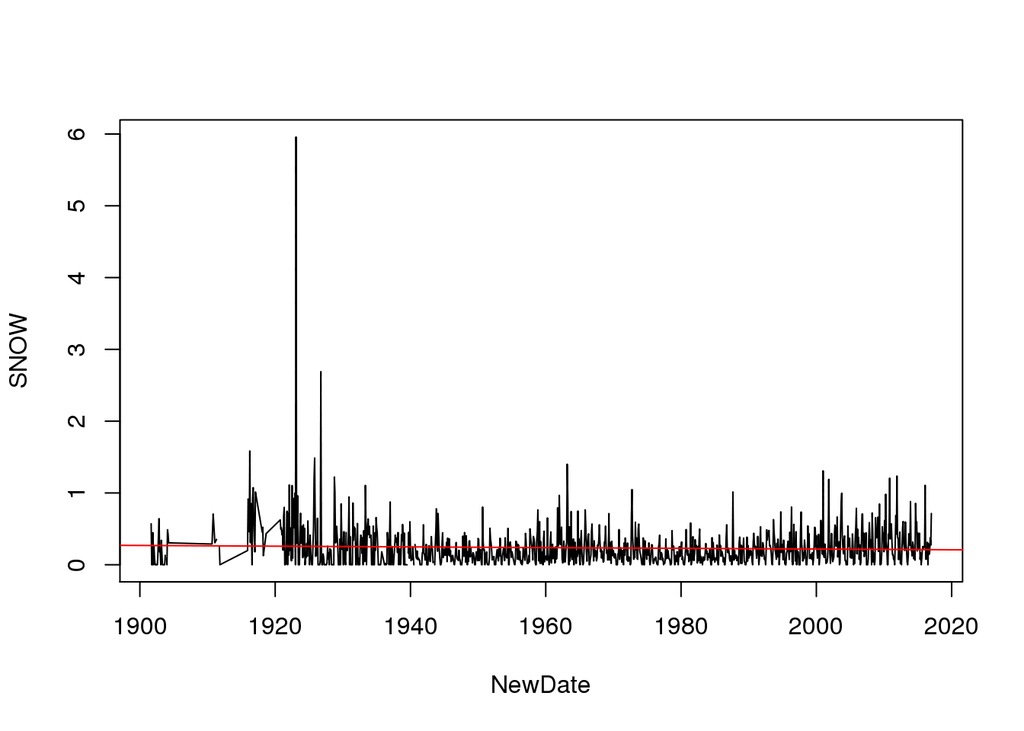

```r
abline(coef(SD.lm), col="red")
```

### Selecting for 3 Months – December, January, February

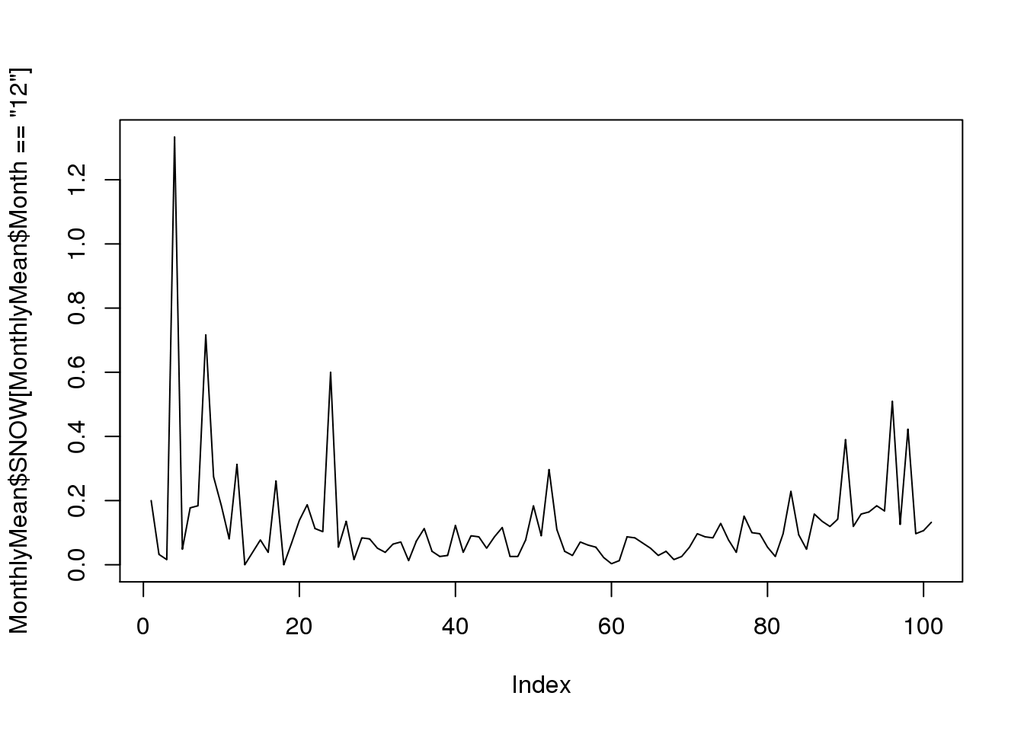

```r
plot(MonthlyMean$SNOW[MonthlyMean$Month=="12"], ty='l')
```

```r
plot(SNOW~YEAR, data=MonthlyMean[MonthlyMean$Month=="12",], ty='l')
December.lm <- lm(SNOW~YEAR, data=MonthlyMean[MonthlyMean$Month=="12",])
summary(December.lm)
```

```
##
## Call:
## lm(formula = SNOW ~ YEAR, data = MonthlyMean[MonthlyMean$Month ==
##     "12", ])
##
## Residuals:
##      Min       1Q   Median       3Q      Max
## -0.15107 -0.08212 -0.04030  0.02876  1.17222
##
## Coefficients:
##               Estimate Std. Error t value Pr(>|t|)
## (Intercept)  1.3609089  1.0752582   1.266    0.209
## YEAR        -0.0006282  0.0005471  -1.148    0.254
##
## Residual standard error: 0.1686 on 99 degrees of freedom
## Multiple R-squared:  0.01314,    Adjusted R-squared:  0.003172
## F-statistic: 1.318 on 1 and 99 DF,  p-value: 0.2537
```

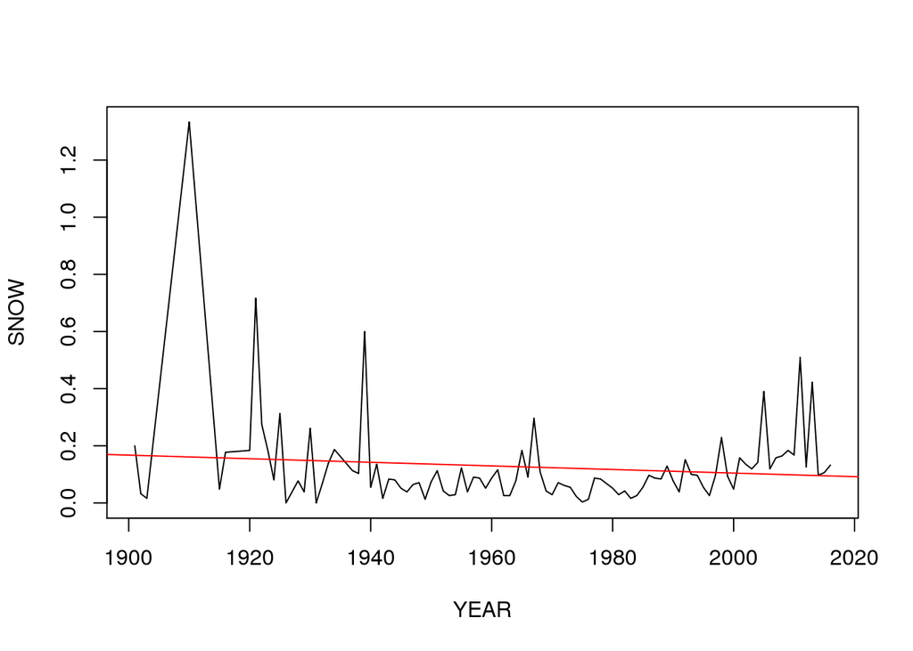

```r
abline(coef(December.lm), col="red")
```

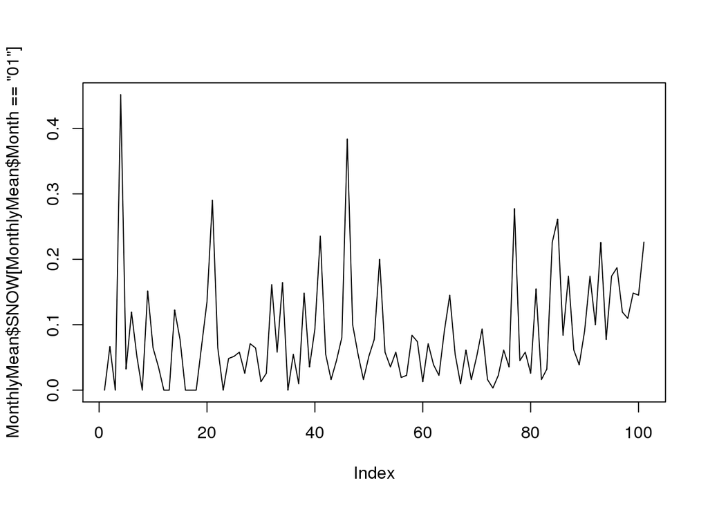

```r
plot(MonthlyMean$SNOW[MonthlyMean$Month=="01"], ty='l')
```

```r
plot(SNOW~YEAR, data=MonthlyMean[MonthlyMean$Month=="01",], ty='l')
January.lm <- lm(SNOW~YEAR, data=MonthlyMean[MonthlyMean$Month=="01",])
summary(January.lm)
```

```
##
## Call:
## lm(formula = SNOW ~ YEAR, data = MonthlyMean[MonthlyMean$Month ==
##     "01", ])
##
## Residuals:
##      Min       1Q   Median       3Q      Max
## -0.09305 -0.06081 -0.02202  0.01737  0.39364
##
## Coefficients:
##               Estimate Std. Error t value Pr(>|t|)
## (Intercept) -0.9472202  0.5324335  -1.779   0.0783 .
## YEAR         0.0005246  0.0002707   1.938   0.0555 .
## ---
## Signif. codes:  0 '***' 0.001 '**' 0.01 '*' 0.05 '.' 0.1 ' ' 1
##
## Residual standard error: 0.08249 on 99 degrees of freedom
## Multiple R-squared:  0.03654,    Adjusted R-squared:  0.02681
## F-statistic: 3.755 on 1 and 99 DF,  p-value: 0.0555
```

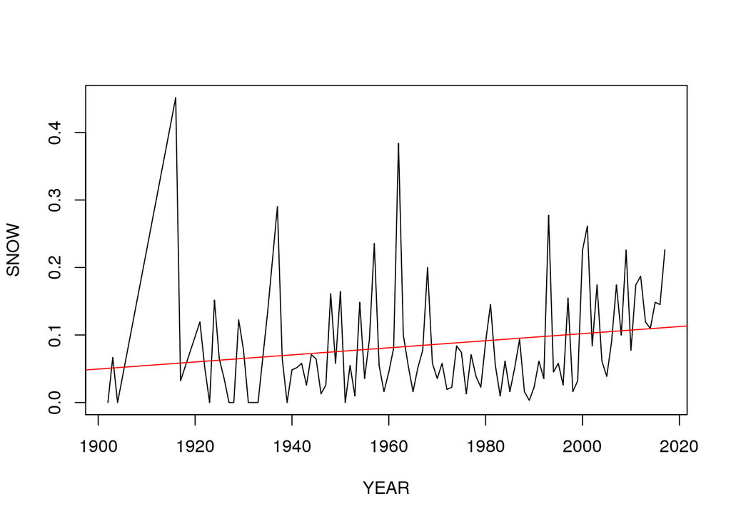

```r
abline(coef(January.lm), col="red")
```

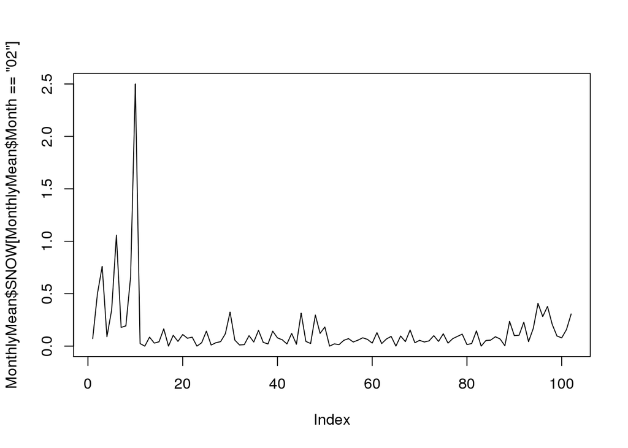

```r
plot(MonthlyMean$SNOW[MonthlyMean$Month=="02"], ty='l')
```

```r
plot(SNOW~YEAR, data=MonthlyMean[MonthlyMean$Month=="02",], ty='l')
February.lm <- lm(SNOW~YEAR, data=MonthlyMean[MonthlyMean$Month=="02",])
summary(February.lm)
```

```
##
## Call:
## lm(formula = SNOW ~ YEAR, data = MonthlyMean[MonthlyMean$Month ==
##     "02", ])
##
## Residuals:
##      Min       1Q   Median       3Q      Max
## -0.22367 -0.12428 -0.05902  0.02522  2.27233
##
## Coefficients:
##               Estimate Std. Error t value Pr(>|t|)
## (Intercept)  4.0654324  1.7757988   2.289   0.0242 *
## YEAR        -0.0019957  0.0009037  -2.208   0.0295 *
## ---
## Signif. codes:  0 '***' 0.001 '**' 0.01 '*' 0.05 '.' 0.1 ' ' 1
##
## Residual standard error: 0.2791 on 100 degrees of freedom
## Multiple R-squared:  0.0465, Adjusted R-squared:  0.03697
## F-statistic: 4.877 on 1 and 100 DF,  p-value: 0.0295
```

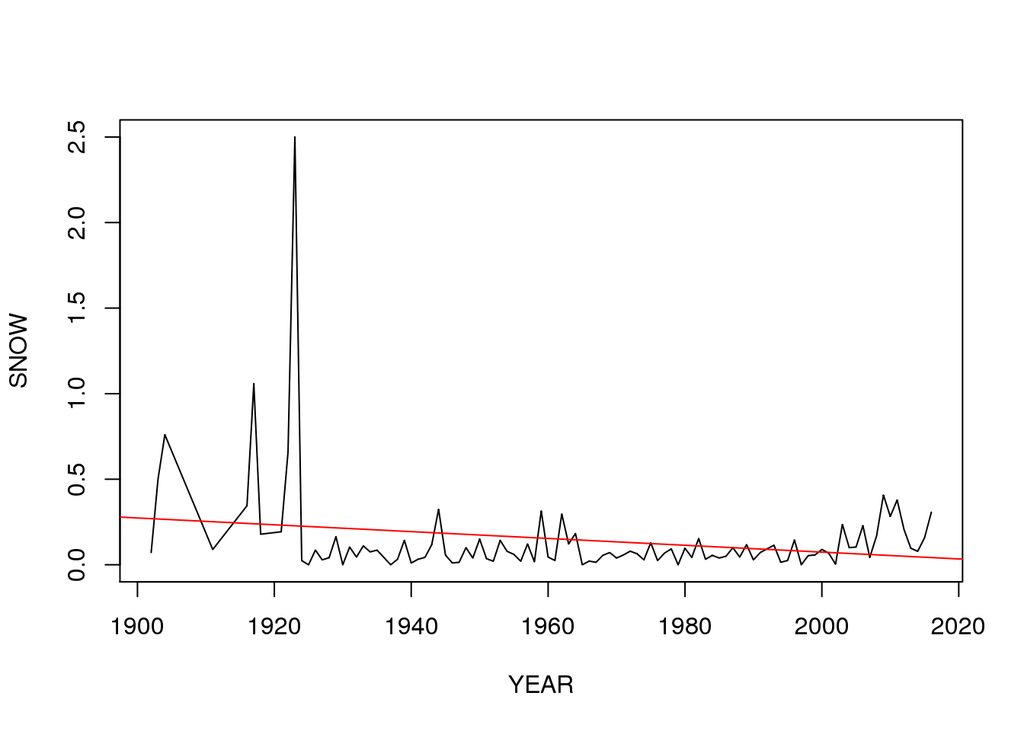

```r
abline(coef(February.lm), col="red")
```